# saulo_gil_atividade02

Saulo Gil

2023-06-27

## Atividade 02

Qual a estatística básica dos gols do Brasil nas Copas que nossa seleção disputou? Qual a relação dessas estatísticas com as vitórias e derrotas para a nossa seleção?

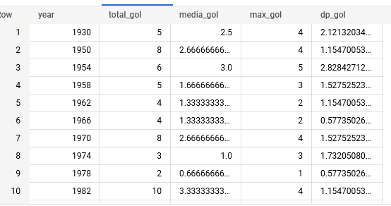

# Estatística descritiva

Os valores descritivos considerando todos os jogos do Brasil em copas do mundo são:

- *Média* = 2.1;
- *Desvio Padrão (DP)* = 1.54;
- *Moda* = 1;
- *Mínimo* = 0;
- *Máximo* = 7;

Ademais estão descritos abaixo os resultados da análise descritiva dos jogos do Brasil em cada uma das copas do mundo.

Tabela 2. Análise descritiva dos jogos do Brasil em cada uma das copas do mundo.

| year | jogos | total_gols | media | DP |
| --- | --- | --- | --- | --- |
| 1930 | 2 | 5 | 2.50 | 2.12 |
| 1934 | 1 | 1 | 1.00 | NA |
| 1938 | 5 | 14 | 2.80 | 2.17 |
| 1950 | 6 | 22 | 3.67 | 2.42 |
| 1954 | 3 | 8 | 2.67 | 2.08 |
| 1958 | 6 | 16 | 2.67 | 2.07 |
| 1962 | 6 | 14 | 2.33 | 1.37 |
| 1966 | 3 | 4 | 1.33 | 0.58 |
| 1970 | 6 | 19 | 3.17 | 1.17 |
| 1974 | 7 | 6 | 0.86 | 1.21 |
| 1978 | 7 | 10 | 1.43 | 1.27 |
| 1982 | 5 | 15 | 3.00 | 1.00 |
| 1986 | 5 | 10 | 2.00 | 1.41 |
| 1990 | 4 | 4 | 1.00 | 0.82 |
| 1994 | 7 | 11 | 1.57 | 1.13 |
| 1998 | 7 | 14 | 2.00 | 1.41 |
| 2002 | 7 | 18 | 2.57 | 1.40 |
| 2006 | 5 | 10 | 2.00 | 1.58 |
| 2010 | 5 | 9 | 1.80 | 1.30 |
| 2014 | 7 | 11 | 1.57 | 1.51 |
| 2018 | 5 | 8 | 1.60 | 0.55 |

# Qual a relação dessas estatísticas com as vitórias e derrotas para a nossa seleção?

## Verificando se o total de gols tem relação com o título da copa do mundo

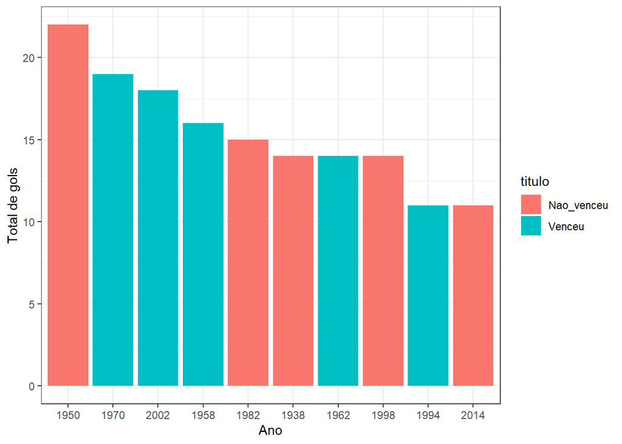

Todos os títulos do estão entre os 10 maiores somatórios de gols em mundiais, indicando que o total de gols é um bom indicador de desempenho em copa do mundo. Porém, como o valor total pode ser facilmente influenciado pelo número total de jogos é importante usar outra métrica que possa considerar o número de jogos. Então, vamos ver a média de gols!!!

## Verificando se a média de gols tem relação com o título da copa do mundo

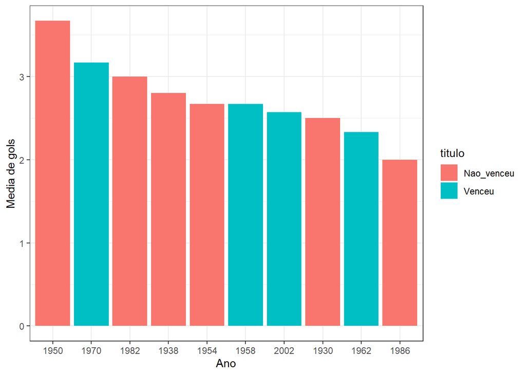